# Step by step tutorial

In this tutorial we will explain how to run the pipeline and perform peakC analysis on the Sox2 4C-seq data from Geeven et al. (SRA files GSM2824300, GSM2824301 and GSM2824302).

## Setup the pipeline

### Download the pipeline including the example files

```
$ wget https://github.com/deLaatLab/pipe4C/archive/master.zip
$ unzip master.zip
$ cd ./pipe4C-master
```

> **note:** the pipe4C.R and functions.R files need to be placed in the same folder.

> The FASTQ files and viewpoint file can be found in the example folder.

### Modify the configuration file (conf.yml) using any plain text editor

- Change the location in which the fragmented genome will be generated (fragFolder).
- Change the location in which the bowtie2 index is stored.

## Run the pipeline

```
Rscript pipe4C.R --vpFile=./example/VPinfo.txt --fqFolder=./example/ --outFolder=./outF/ --cores 8 --plot --wig
```

This will run the pipeline using 8 cores and generates a viewpoint plot and wig file as output, next to the default outputs.

## Check the report file

the report file indicates that the quality of the experiment is good.

- ~80% of the reads map to the viewpoint chromosome (fragMappedCisPercCorr).
- ~75% of the reads mapping to the viewpoint chromosome maps within 1MB from the viewpoint (cov1Mb).
- Furthermore ~90% of the mappable DpnII fragment ends within 100kb from the viewpoint (capt100Kb) have at least one read.

## Have a look at the viewpoint plots

A coverage plot of the viewpoint region is generated based on the normalized and smoothened data. The genomic region that is visualized, the height of the Y-axis, the unit of the X-axis (Mb, kb, bp) and the file type (PDF or PNG) are defined and can be adjusted in the configuration file. In addition the quality metrics are displayed in this figure for a quick impression of the data.

## load peakC package and pipe4C functions

To run peakC on the rds files created by the pipe4C pipeline, you need to load the peakC R-package (make sure it’s installed first!) and source the pipe4C functions in R:

```r
library(peakC)
pipe4CFunctionsFile <- "functions.R"
source(pipe4CFunctionsFile)
```

Next, you need to select rds files (output from the pipe4C pipeline) from 4C-Seq experiments that you want to analyze. For example, we can re-analyze the data from the peakC paper:

```r
resultsDir <- "./outF/RDS/"
```

To analyze data from the Sox2 viewpoint in mouse ES cells (which is referred to as set_1_viewpoint_10_ESC), we select these as follows

```r
rdsFiles <- paste0(resultsDir,c("set_1_viewpoint_10_ESC_replicate_1.rds","set_1_viewpoint_10_ESC_replicate_2.rds", "set_1_viewpoint_10_ESC_replicate_3.rds"))
```

Now we can run peakC, with the default parameters

```r
resPeakC <- doPeakC(rdsFiles = rdsFiles)
```

and plot the results

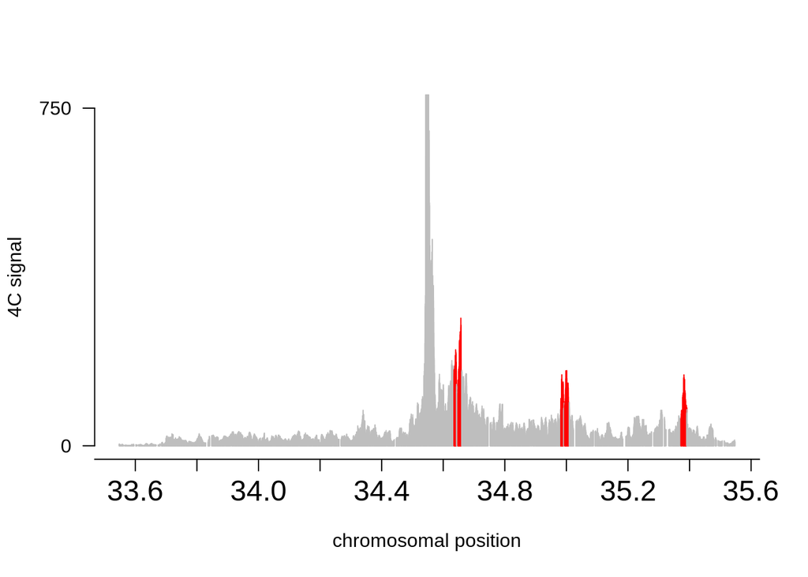

```r
plot_C(resPeakC,y.max=750)
```

Finally, we extract the identified peak regions from the peakC analysis from the objects and export the results in a BED file which can be used for visualization in a genome browser together with the generated wig files.

```r
resPeaks <- getPeakCPeaks(resPeakC=resPeakC)
peaksFile <- "./outF/set_1_viewpoint_10_ESC_peakC_peaks.bed"
exportPeakCPeaks(resPeakC=resPeakC,bedFile=peaksFile,name="set_1_viewpoint_10_ESC_peakC_peaks")
```